# PL4246 Example Final Report

## Short Dark Triad (SD3): A Brief Measure of Dark Personality Traits

- 27 item psychometric network
- edges are significant partial/conditional correlations
- 9 items each for Machiavellianism, narcissism, psychopathy

You can do the test here (and maybe keep the results to yourself :P): https://openpsychometrics.org/tests/SD3/

## Items

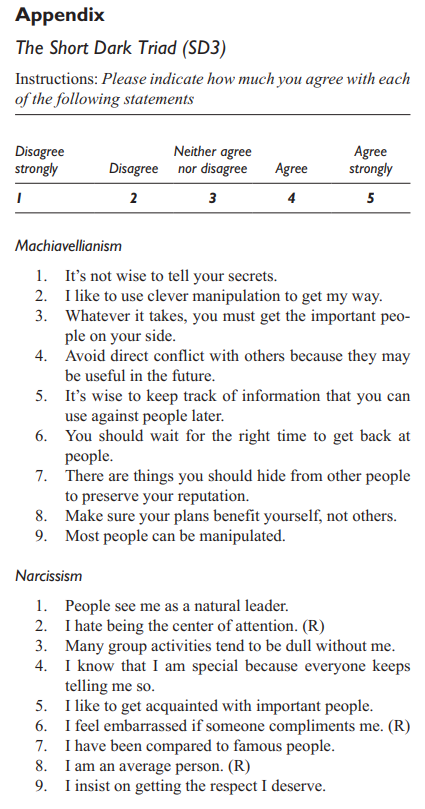

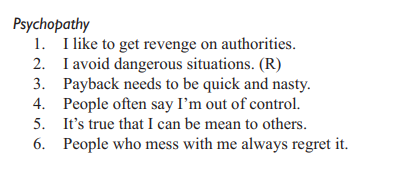

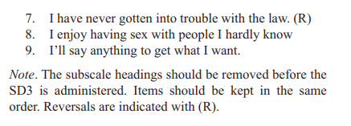

## A poor report

- brute-force, applies all or several network metrics to the network
- little or weak connection to the literature
- discussion of network analysis results is superficial
- research question not well articulated or unclear how network analysis contributes to answering it

## Examples of good research questions (for this network)

1. Evaluation of whether the three factor solution is replicated in a community detection analysis (*meso-level, more descriptive/exploratory*)
- does the community detection reveal 3 communities? do the different methods give the same patterns? are the detected communities robust?
- do the communities correspond to the three dark personality traits (Machiavellianism, narcissism, psychopathy)?
- how close is this correspondence? which items deviated from their original label?

## Examples of good research questions (for this network)

2. Testing if a hypothesized core construct is a core node in the network (*micro-level, more hypothesis-driven*)
- in this literature, it is commonly assumed that a commonality across the dark triad is *“interpersonal manipulation”* (Jones & Figueredo, 2012; Wai & Tiliopoulos, 2012)
- this implies that items associated with this trait should be highly central nodes in this network
- identify specific items that align with this construct
- compare their centrality scores (e.g., degree, strength… and explain why these ones) - is it relatively higher than other nodes?

## References

Jones, D. N., & Figueredo, A. J. (2012). The core of darkness: Uncovering the heart of the Dark Triad. *European Journal of Personality*. Advance online publication. doi:10.1002/per.1893

Wai, M., & Tiliopoulos, N. (2012). The affective and cognitive empathic nature of the Dark Triad of personality. *Personality and Individual Differences, 52*, 794-799.

Jones, D. N., & Paulhus, D. L. (2014). Introducing the short dark triad (SD3) a brief measure of dark personality traits. *Assessment, 21*(1), 28-41.